# Linear Regression Problem Set

# 1 Simple Linear Regresion -

For this problem, use the data set that relates the results of a simulation that predicts kills as a function ofweapon system caliber. It is available here .

## 1.1 Initial Plotting

Plot the observations and comment on the suitability of using linear regression for this data.

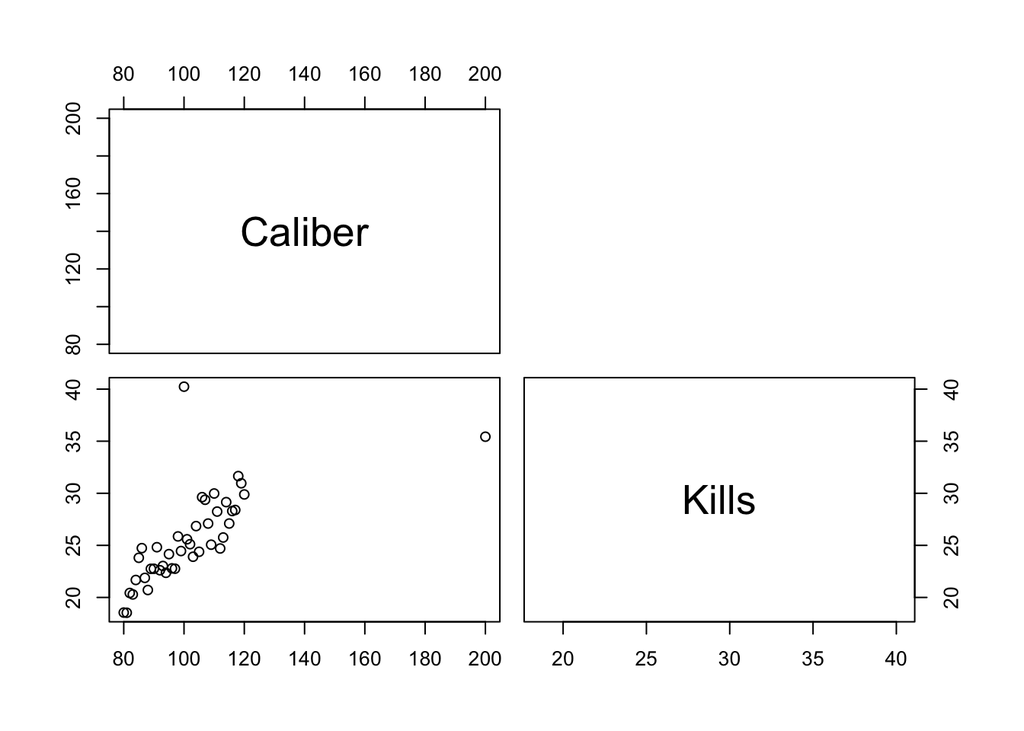

```r
# We'll use the tidyverse throughout this problem set
library(tidyverse)

# Read the data
p1 <- read.csv('./simple_regression_data.csv')

# We can plot this as a pairs graph
pairs(p1, upper.panel = NULL)
```

```r
# The data looks approximately linear, though there's at least one clear outlier and point of high leverage
```

## 1.2 Model

Build a linear model, comment on the summary output. Is this a good model (not including diagnostic checks)?

```r
p1.LM <- lm(Kills ~ Caliber, p1)
summary(p1.LM)
```

```
##
## Call:
## lm(formula = Kills ~ Caliber, data = p1)
##
## Residuals:
##     Min      1Q  Median      3Q     Max
## -5.1648 -1.7583 -0.5454  0.9803 14.9878
##
## Coefficients:
##             Estimate Std. Error t value Pr(>|t|)
## (Intercept)  9.89730    2.64429   3.743 0.000572 ***
## Caliber      0.15349    0.02538   6.047 4.06e-07 ***
## ---
## Signif. codes:  0 '***' 0.001 '**' 0.01 '*' 0.05 '.' 0.1 ' ' 1
##
## Residual standard error: 3.161 on 40 degrees of freedom
## Multiple R-squared:  0.4776, Adjusted R-squared:  0.4645
## F-statistic: 36.56 on 1 and 40 DF,  p-value: 4.063e-07
```

```r
# The coefficients are clearly signific ant
# The residuals are OK... but the R^2 appears to miss something causing significant variability in the model
```

Plot the model and compare it to the observations.

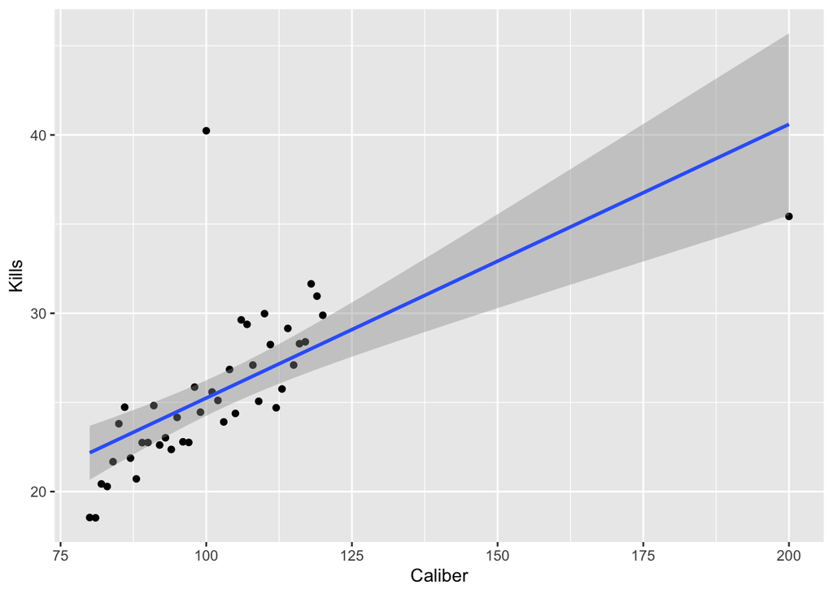

```r
ggplot(p1, aes(x = Caliber, y = Kills)) +
  geom_point() +
  stat_smooth(method ='lm')
```

```r
# We see two things, this model is clearly linear.  Though we get wide variance in our prediction as we move toward the high leverage point
# We can also see how this is probably throwing off our model.
```

## 1.3 Assumptions

1. Does your model meet the assumptions of linearity, independence, normality and homoscedsticity of residuals?

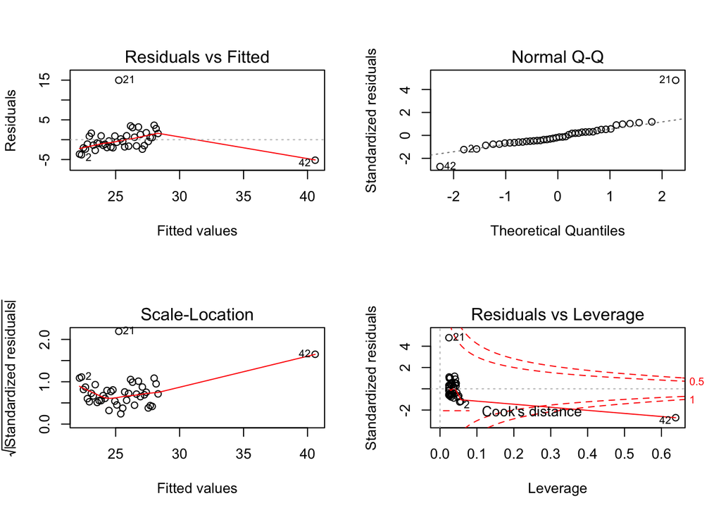

```r
par(mfrow = c(2,2))
plot(p1.LM)
```

```r
# We can see we appear to have constant variance and normality and independence.
# We just have a couple points that appear to have very high leverage and are residuals
# We can calculate normality and homoscedasticity quantiatively

shapiro.test(p1.LM$residuals)
```

```
##
##  Shapiro-Wilk normality test
##
## data:  p1.LM$residuals
## W = 0.77873, p-value = 1.607e-06
```

```r
car::ncvTest(p1.LM)
```

```
## Non-constant Variance Score Test
## Variance formula: ~ fitted.values
## Chisquare = 0.9447402, Df = 1, p = 0.33106
```

```r
# We fail normality, but do pass constant variance
```

2. Do you have outliers or points with high influence?

```r
# We see both points 21 and 42 from our graphs appear to be outliers and have high leverage respectively
```

3. If you have no problematic points, skip to the next question. If you do, make a decision about what to do with them, justify it, and then produce a new model (if necessary).

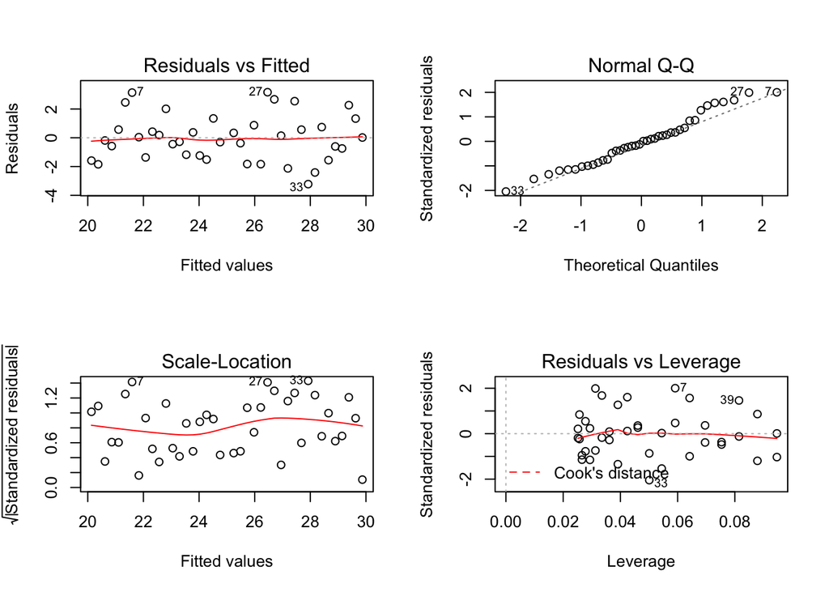

```r
# Let's drop points 21 and 42.  They appear to significantly affect our results.
# If we had the model and results, we could check those runs more closely

# Drop these points
p1.drop <- p1[-c(21, 42),]
# build the model
p1.drop.LM <- lm(Kills ~ Caliber, p1.drop)
# check the model
par(mfrow = c(2,2))
plot(p1.drop.LM)
```

```r
# The new model appears to be much better
shapiro.test(p1.drop.LM$residuals)
```

```
##
##  Shapiro-Wilk normality test
##
## data:  p1.drop.LM$residuals
## W = 0.97055, p-value = 0.3746
```

```r
car::ncvTest(p1.drop.LM)
```

```
## Non-constant Variance Score Test
## Variance formula: ~ fitted.values
## Chisquare = 0.5161514, Df = 1, p = 0.47249
```

```r
# We quantitatively have a better model
```

If you produced a new model, plot it and your observations here. Compare this with your original model.

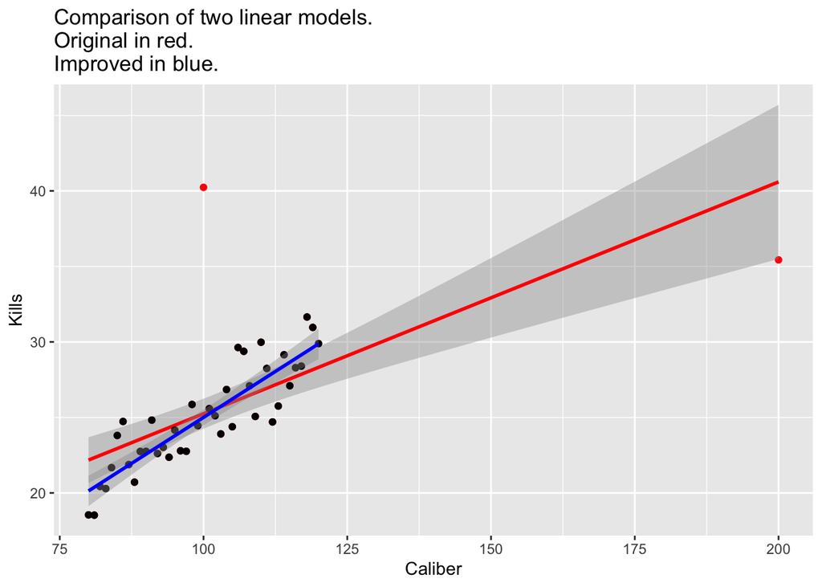

```r
# We can plot both on top of each other with the original in red and the corrected model in blue
# The two outlier points we have are plotted in red
ggplot() +
  # Original model
  geom_point(data = p1, aes(x = Caliber, y = Kills), color = 'red') +
  stat_smooth(method = 'lm', data = p1, aes(x = Caliber, y = Kills), color = 'red')  +
  # Improved model
  geom_point(data = p1.drop, aes(x = Caliber, y = Kills)) +
  stat_smooth(method = 'lm', data = p1.drop, aes(x = Caliber, y = Kills), color = 'blue') +
  ggtitle('Comparison of two linear models.\nOriginal in red.\nImproved in blue.')
```

```r
# We can see how our improved model is much truer to the majority of the data
# this prevents us from extrapolating too much beyond based on a single data point
```

## 1.4 Prediction

1. Write down your model mathematically.

$$K = 0.65 + 0.24 \cdot C + \epsilon$$

Where K is number of kills and C is the caliber.

2. Use your best model to predict the number of kills associated with weapons with calibers of 81, 105, and 120mm. Provide a confidence interval bound. What does this tell us?

```r
predict(p1.drop.LM, list(Caliber = c(81, 105, 120)), interval = 'confidence')
```

```
##        fit      lwr      upr
## 1 20.37516 19.40460 21.34572
## 2 26.21854 25.65764 26.77945
## 3 29.87066 28.86329 30.87803
```

```r
# This tells us that if we took repeated measurements of kills at these calibers, our mean result would fall in these bounds with 95% confidence
```

# 2 Simple Linear Regression - Iris

For this problem we are going to use the built in *R* data set, `iris`. You can read about the data set in the help file (`?iris`).

## 2.1 Model

Develop a simple linear regression for the relationship between Petal.Length and Sepal.Length using Petal.Length as the response. Interpret the results. Specifically comment on:

- What coefficients are significant at $\alpha = .05$. Interpret their meaning.
- What the residual and coefficient standard errors are and how you interpret them.
- What the coefficient of determination is and how you can interpret that.
- What the resulting model is.

```r
# I don't want to write over any data, so we'll copy it and only take the data we need
myData <- iris %>% select(Petal.Length, Sepal.Length)

# Build the regression
myModel <- lm(Petal.Length ~ Sepal.Length, data = myData)
# View the summary
summary(myModel)
```

```
##
## Call:
## lm(formula = Petal.Length ~ Sepal.Length, data = myData)
##
## Residuals:
##      Min       1Q   Median       3Q      Max
## -2.47747 -0.59072 -0.00668  0.60484  2.49512
##
## Coefficients:
##              Estimate Std. Error t value Pr(>|t|)
## (Intercept)  -7.10144    0.50666  -14.02   <2e-16 ***
## Sepal.Length  1.85843    0.08586   21.65   <2e-16 ***
## ---
## Signif. codes:  0 '***' 0.001 '**' 0.01 '*' 0.05 '.' 0.1 ' ' 1
##
## Residual standard error: 0.8678 on 148 degrees of freedom
## Multiple R-squared:   0.76,  Adjusted R-squared:  0.7583
## F-statistic: 468.6 on 1 and 148 DF,  p-value: < 2.2e-16
```

- The intercept is -7.10cm. and is significant (p-value ~ 0). This is simply the y intercept for our model.
- The Sepal.Length coefficient is 1.9 and is significant (p-value ~0). This means for every additional cm of Sepal Length, you gain an additional 1.9cm of Petal Length.
- The standard error on the intercept is .51, the standard error on sepal length is .086, and the residual standard error is .87. These all show the variability in our estimates, specifically they show us how much confidence we can have in our model.
- The coefficient of determination ($R^2$) is .76, which explains much of the variability in our model. This, combined with relatively low standard errors indicates we have a reasonably useful model.
- Our model is:

$$Petal.Length = -7.10 + 1.86 \cdot Sepal.Length + \epsilon$$

## 2.2 Visualization

Plot the data and the assessed model. Interpret your visualization

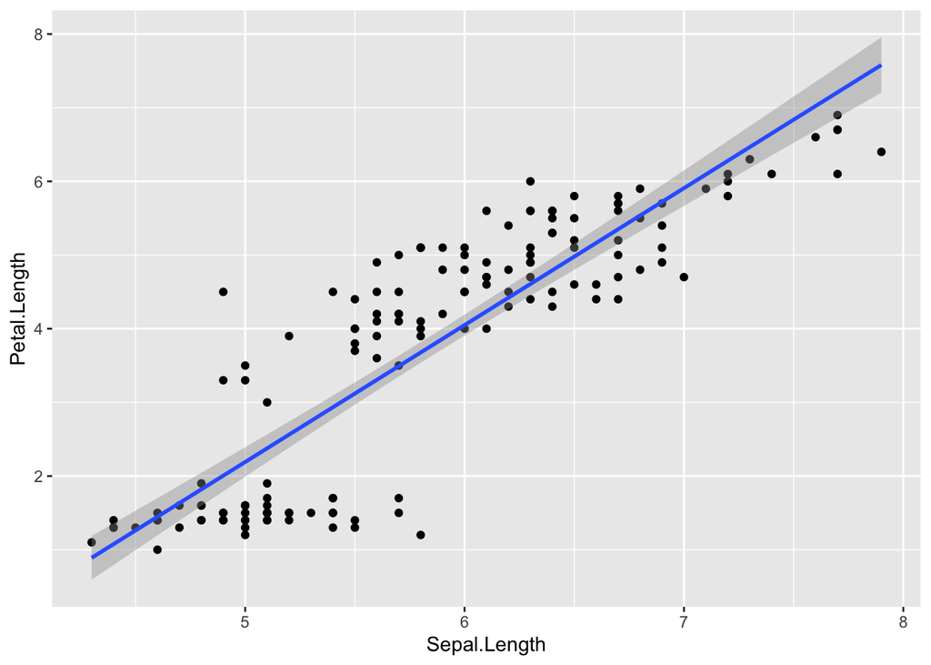

```r
ggplot(myData, aes(x = Sepal.Length, y = Petal.Length)) +
  geom_point() +
  stat_smooth(method = 'lm')
```

```r
# We see that there is an approximately linear relationship in our data.
# However, it appears as if there is something else going on.  For example
# look in the bottom left of the plot and see how it appears as if we have
# a couple differnt groups in our data or something else going on
# As we progress in this lesson we'll ID these and be able to plot categorical variables
```

## 2.3 Prediction

Calculate the 95% and 90% confidence intervals on your regression’s coefficients.

```r
# 95%
confint(myModel, level = .95)
```

```
##                  2.5 %    97.5 %
## (Intercept)  -8.102670 -6.100217
## Sepal.Length  1.688772  2.028094
```

```r
# 90%
confint(myModel, level = .9)
```

```
##                    5 %      95 %
## (Intercept)  -7.940078 -6.262809
## Sepal.Length  1.716323  2.000542
```

Predict the petal length and confidence bounds on that prediction (for the mean response) for the sepal length associated with every 10th percentile of the sepal length data (i.e. the 10th percentile of the data is 4.80, etc..):

```
##        fit      lwr      upr
## 1 1.819035 1.593337 2.044733
## 2 2.190722 1.990526 2.390917
## 3 2.692498 2.522005 2.862992
## 4 3.305781 3.159800 3.451762
## 5 3.677468 3.537253 3.817682
## 6 4.234998 4.088361 4.381635
## 7 4.606684 4.446656 4.766713
## 8 5.015540 4.834470 5.196609
## 9 5.721744 5.494267 5.949221
```